# ASA Section Membership Exploratory Analysiss

Thelonious Goerz

2023-07-02

## Which subject areas of sociological research are the most popular?

This is an interesting question for two reasons: 1) it provides insight about the questions and phenomena that gain the most prominence in the field. 2) analyzing historical trends in membership allows researchers to understand the growth in or maintenance of popularity of different topics within the discipline. Both of these questions aid in reexamination and study of the production of sociological research questions. Crucially, it can also illuminate gaps in current sociological study that deserve more attention. Ahead of the 2023 meeting, I thought I would compile this exploratory document to provide insight about section membership. I examine trends in topical section membership for the 53 current sections of the American Sociological Association (ASA).

*Note*: These visualizations are a work in progress.

### Data

Data on ASA section membership were obtained from the [ASA](https://www.asanet.org/communities-and-sections/sections/section-membership-data/) website. The data were downloaded in .pdf form and read in to `R` for processing. Section data were scraped using the `tabulizer` package and processed for use in this document. Details and code for this procedure are in the `DataPrep.R` file in this repository.

### Descriptive statistics

In this section, I display summary statistics of section membership for all 53 sections between 2008-2022 arranged by mean section rank by membership count.

```r
# %%%%%%%%%%%%%%%%%
# Create a descriptive table with average membership counts (2008-2022) for each section.
# %%%%%%%%%%%%%%%%%

Desc_1 <- Data %>%
  group_by(SectionName) %>%
  summarise("Mean Members" = round(mean(MembershipCount, na.rm = T),2),
            "SD Members" = round(sd(MembershipCount,na.rm = T),2),
            "Min Members" = min(MembershipCount, na.rm = T),
            "Max Members" = max(MembershipCount,na.rm = T),
            "Mean Rank" = round(mean(Rank, na.rm = T),2)) %>%
  arrange(`Mean Rank`) %>%
  knitr::kable()

Desc_1
```

| SectionName | Mean Members | SD Members | Min Members | Max Members | Mean Rank |
| --- | --- | --- | --- | --- | --- |
| Racial and Ethnic Minorities | 884.13 | 63.05 | 811 | 1049 | 4.07 |
| Political Sociology | 831.33 | 37.42 | 780 | 901 | 5.27 |
| Theory | 810.40 | 40.15 | 735 | 859 | 6.53 |
| Collective Behavior and Social Movements | 796.60 | 51.07 | 697 | 874 | 7.20 |
| Economic Sociology | 785.93 | 49.54 | 701 | 872 | 8.00 |
| Race, Gender, and Class | 971.31 | 69.96 | 900 | 1154 | 8.27 |
| Sociology of Education | 774.07 | 62.30 | 648 | 862 | 8.80 |
| Comparative-Historical Sociology | 737.80 | 49.06 | 681 | 815 | 10.27 |
| Family | 730.13 | 83.03 | 573 | 822 | 11.47 |
| Teaching and Learning in Sociology | 705.67 | 78.30 | 589 | 813 | 12.53 |
| Social Psychology | 631.60 | 43.04 | 549 | 692 | 15.47 |
| International Migration | 626.33 | 33.49 | 561 | 680 | 15.53 |
| Inequality, Poverty, and Mobility | 796.17 | 100.89 | 545 | 907 | 16.33 |
| Community and Urban Sociology | 627.67 | 48.68 | 552 | 727 | 16.40 |
| Global and Transnational Sociology | 673.85 | 55.70 | 516 | 727 | 17.47 |
| Crime, Law, and Deviance | 603.93 | 52.33 | 502 | 701 | 17.73 |
| Aging and the Life Course | 586.60 | 40.70 | 501 | 624 | 18.33 |
| Science, Knowledge, and Technology | 554.00 | 50.77 | 477 | 621 | 18.80 |
| Sociology of Religion | 570.27 | 97.97 | 421 | 698 | 19.20 |
| Environmental Sociology | 501.93 | 29.38 | 461 | 568 | 21.80 |
| Organizations, Occupation, and Work | 935.33 | 53.95 | 819 | 996 | 21.87 |
| Sociology of Population | 501.00 | 24.92 | 454 | 549 | 21.93 |
| Sociology of Sexualities | 500.20 | 42.65 | 442 | 580 | 21.93 |
| Sociology of Law | 422.13 | 19.12 | 400 | 479 | 26.40 |
| Methodology | 407.40 | 19.77 | 374 | 434 | 27.33 |
| Labor and Labor Movements | 399.53 | 25.61 | 352 | 435 | 27.93 |
| Children and Youth | 402.73 | 34.06 | 342 | 447 | 28.33 |
| Political Economy of the World-System | 378.40 | 50.75 | 291 | 431 | 29.93 |
| Latina/o Sociology | 378.27 | 31.22 | 318 | 419 | 30.40 |
| Asia and Asian America | 371.20 | 36.81 | 313 | 446 | 30.47 |
| Medical Sociology | 957.00 | 29.39 | 918 | 993 | 30.60 |
| Sociology of Development | 451.92 | 50.10 | 357 | 507 | 30.93 |
| Sociology of Mental Health | 361.93 | 62.08 | 277 | 457 | 31.33 |
| Sociology of Culture | 981.00 | 27.59 | 948 | 1028 | 31.60 |
| Communication, Information Technologies, and Media Sociology | 352.20 | 32.74 | 317 | 437 | 31.87 |
| Sociology of Sex and Gender | 1082.17 | 37.16 | 1025 | 1121 | 32.33 |
| Marxist Sociology | 325.60 | 39.14 | 259 | 414 | 34.33 |
| Sociological Practice and Public Sociology | 316.80 | 32.45 | 215 | 362 | 34.33 |
| Peace, War, and Social Conflict | 293.67 | 30.46 | 231 | 330 | 37.53 |
| Sociology of Body and Embodiment | 295.50 | 28.10 | 220 | 321 | 37.93 |
| Sociology of Human Rights | 266.40 | 34.51 | 221 | 321 | 39.53 |
| Altruism, Morality, and Social Solidarity | 263.14 | 50.30 | 139 | 320 | 39.60 |
| Sociology of Emotions | 255.00 | 16.66 | 226 | 278 | 40.27 |
| Mathematical Sociology | 232.20 | 35.05 | 205 | 312 | 40.87 |
| Disability in Society | 223.27 | 53.10 | 165 | 331 | 42.20 |
| Sociology of Consumers and Consumption | 264.64 | 44.67 | 196 | 322 | 42.53 |
| History of Sociology and Social Thought | 203.27 | 25.06 | 168 | 272 | 43.13 |
| Drugs and Society (formerly Alcohol, Drugs, and Society) | 185.20 | 44.47 | 128 | 288 | 44.20 |
| Animals and Society | 151.67 | 17.51 | 112 | 180 | 46.40 |
| Ethnomethodology and Conversation Analysis | 141.93 | 24.97 | 113 | 199 | 47.47 |
| Rationality and Society | 141.80 | 25.71 | 104 | 205 | 47.47 |
| Evolution, Biology, and Society | 136.47 | 37.62 | 82 | 203 | 47.60 |
| Sociology of Indigenous Peoples and Native Nations | 205.00 | 58.97 | 138 | 249 | 50.93 |

### Visualizing membership

In the figure below, I present a variety of visualizations of interesting trends in the membership data. Firstly, I display a bar chart representing the most recent (five years) data on the top ten ASA sections by membership.

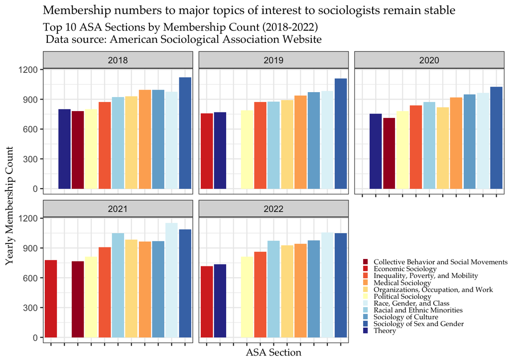

```r
# %%%%%%%%%%%%%%%%%
# Create a plot that shows the membership counts of the top 10 sections in the past five years.
# Sections are color-coded with a legend at the bottom and faceted.
# %%%%%%%%%%%%%%%%%
Plot_1 <- Data %>%
  group_by(Year) %>%
  filter(Rank <11 & Year %in% c(2018:2022)) %>%
  ggplot(aes(fct_reorder(SectionName,
                         MembershipCount),
                         MembershipCount,
                         fill = SectionName)) +
  geom_col() +
  facet_wrap(~Year) +
  theme_bw() +
  scale_fill_brewer(palette = "RdYlBu") +
  theme(
       plot.title = element_text(family = "Palatino", size =12),
       plot.subtitle = element_text(family = "Palatino"),
       axis.title.x = element_text(family = "Palatino", size = 10),
       axis.title.y = element_text(family = "Palatino", size = 10),
       axis.text.x = element_blank(),
       legend.text = element_text(family = "Palatino", size = 7),
       legend.position= c(0.85, 0.2),
       legend.key.size = unit(.20,"cm")
       ) +
       guides(
       fill=guide_legend(title="")) +
       labs(x = "ASA Section",
       y = "Yearly Membership Count",
       title = "Membership numbers to major topics of interest to sociologists remain stable",
       subtitle = "Top 10 ASA Sections by Membership Count (2018-2022)  \n Data source: American Sociological Association Website"
       )

Plot_1
```

# 2022 Membership

In the figure below, I plot the 2022 membership counts of ASA sections. Of the top sections, only two surpass a thousand members. These two sections “Race, Gender, and Class” and “Sociology of Sex and Gender” both unsurprisingly are focused on major identity categories at the center of sociological research. Next, there are a handful of sections between 750-1000 members, then a sizable mass between 500-750, then the rest of the sections fall below 500 members each.

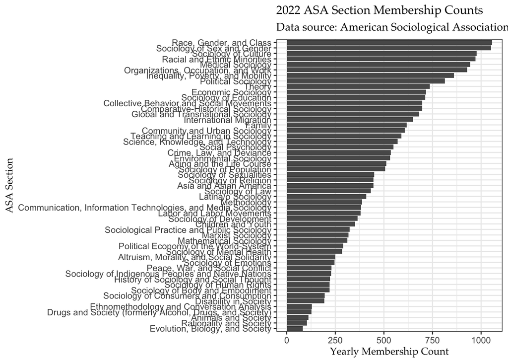

```r
# Create a plot ranking the sections by membership in 2022
Data %>%
  filter(Year == 2022) %>%
  ggplot(aes(x = fct_reorder(SectionName, MembershipCount), y = MembershipCount)) +
  geom_col() + coord_flip() +
  theme_bw() +
  theme(
       plot.title = element_text(family = "Palatino", size =12),
       plot.subtitle = element_text(family = "Palatino"),
       axis.title.x = element_text(family = "Palatino", size = 10),
       axis.title.y = element_text(family = "Palatino", size = 10),
       legend.text = element_text(family = "Palatino", size = 7),
       legend.position= c(0.85, 0.2),
       legend.key.size = unit(.20,"cm")
       ) +
       guides(
       fill=guide_legend(title="")) +
       labs(x = "ASA Section",
       y = "Yearly Membership Count",
       title = "2022 ASA Section Membership Counts",
       subtitle = "Data source: American Sociological Association Website"
       )
```